# Guía 2 - Ejercicio 3

3. Consideremos para el data set abalone.txt el modelo de clasificación logística basado en la longitud, el peso total y la cantidad de anillos (realizado en el ejercicio 1, ítem d). En vez de considerar el umbral de clasificación en 0.5, probaremos distintos valores en una grilla entre 0 y 1. Una vez entrenado el clasificador logístico usando un 70 % de los datos, consideremos diversos valores de corte para el umbral para hacer el análisis sobre el 30 % restante de los datos de evaluación. Para cada uno de esos umbrales θ, calcular:

$$TPR(θ) = \frac{TP(θ)}{TP(θ) + FN(θ)}$$
$$FPR(θ) = \frac{FP(θ)}{TN(θ) + FP(θ)}$$

Graficamos entonces una curva de FPR (eje x) vs TPR (eje y), llamada la curva ROC. El punto (0,1) del espacio ROC corresponde a un clasificador óptimo. Cualquier punto en la diagonal sería un clasificador perfectamente aleeatorio, mientras que en (1,0) tendremos un clasificador perfectamente malo (que también es óptimo si uno invierte sus interpretaciones).  
Para cada umbral, calcular la distancia del punto (fpr, tpr) con respecto al vértice (0,1) o (1,0) más cercano.  
Graficar una curva de umbral vs distancia y determinar así el mejor umbral. Arme la matriz de confusión correspondiente a dicho umbral con el 30 % de los datos separados.

Antes que nada, se cargará el dataset con el que se trabajará:

Visualicemos la estructura de estos datos:

|  | Género | Longitud | Diámetro | Altura | Peso.completo | Peso.Carne | Peso.Vísceras | Peso.Caparazón | Anillos |
| --- | --- | --- | --- | --- | --- | --- | --- | --- | --- |
| 1 | M | 0.455 | 0.365 | 0.095 | 0.5140 | 0.2245 | 0.1010 | 0.150 | 15 |
| 2 | M | 0.350 | 0.265 | 0.090 | 0.2255 | 0.0995 | 0.0485 | 0.070 | 7 |
| 3 | F | 0.530 | 0.420 | 0.135 | 0.6770 | 0.2565 | 0.1415 | 0.210 | 9 |
| 4 | M | 0.440 | 0.365 | 0.125 | 0.5160 | 0.2155 | 0.1140 | 0.155 | 10 |
| 5 | I | 0.330 | 0.255 | 0.080 | 0.2050 | 0.0895 | 0.0395 | 0.055 | 7 |
| 6 | I | 0.425 | 0.300 | 0.095 | 0.3515 | 0.1410 | 0.0775 | 0.120 | 8 |

|  | Género | Longitud | Diámetro | Altura | Peso.completo | Peso.Carne | Peso.Vísceras | Peso.Caparazón | Anillos | Adulto |
| --- | --- | --- | --- | --- | --- | --- | --- | --- | --- | --- |
| 1 | M | 0.455 | 0.365 | 0.095 | 0.5140 | 0.2245 | 0.1010 | 0.150 | 15 | TRUE |
| 2 | M | 0.350 | 0.265 | 0.090 | 0.2255 | 0.0995 | 0.0485 | 0.070 | 7 | TRUE |
| 3 | F | 0.530 | 0.420 | 0.135 | 0.6770 | 0.2565 | 0.1415 | 0.210 | 9 | TRUE |
| 4 | M | 0.440 | 0.365 | 0.125 | 0.5160 | 0.2155 | 0.1140 | 0.155 | 10 | TRUE |
| 5 | I | 0.330 | 0.255 | 0.080 | 0.2050 | 0.0895 | 0.0395 | 0.055 | 7 | FALSE |
| 6 | I | 0.425 | 0.300 | 0.095 | 0.3515 | 0.1410 | 0.0775 | 0.120 | 8 | FALSE |

Vamos a definir ahora un modelo de regresión logística en el que a partir de: Longitud, Peso completo y cantidad de Anillos podamos predecir si el abalone es adulto o infante, para lo cual lo primero que debemos hacer es separar el dataset en train y test:

[output not shown]

[output cut: 556 more lines]

[output not shown]

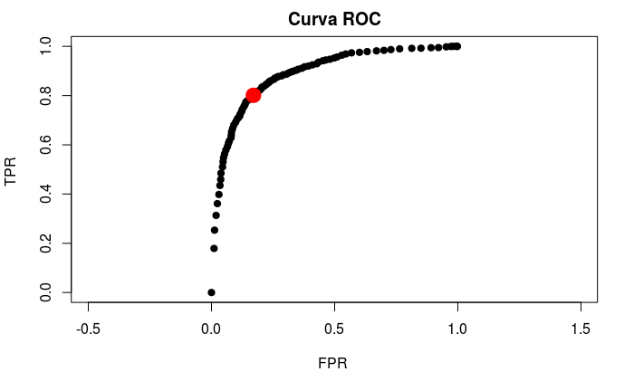

```
[1] "El valor de umbral correspondiente a la curva ROC que está mas cerca del punto (0,1) es:"
[1] 0.64
```

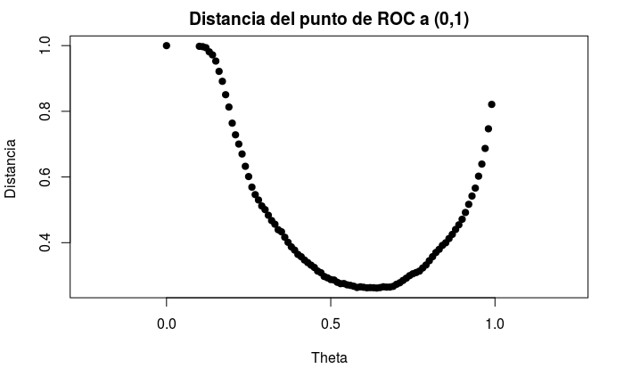

```r
calcula_roc(train$Adulto,train$predict_Adulto,0.01)
```